# Human Activity Recognition

Shreya Shukla

## Problem Statement

Using devices such as Jawbone Up, Nike FuelBand, and Fitbit it is now possible to collect a large amount of data about personal activity relatively inexpensively. These type of devices are part of the quantified self movement - a group of enthusiasts who take measurements about themselves regularly to improve their health, to find patterns in their behavior, or because they are tech geeks. One thing that people regularly do is quantify how much of a particular activity they do, but they rarely quantify how well they do it. In this project, your goal will be to use data from accelerometers on the belt, forearm, arm, and dumbell of 6 participants. They were asked to perform barbell lifts correctly and incorrectly in 5 different ways. More information is available from the website here: http://web.archive.org/web/20161224072740/http:/groupware.les.inf.puc-rio.br/har (see the section on the Weight Lifting Exercise Dataset).

Data

The training data for this project are available here:

https://d396qusza40orc.cloudfront.net/predmachlearn/pml-training.csv

The test data are available here:

https://d396qusza40orc.cloudfront.net/predmachlearn/pml-testing.csv

The data for this project come from this source: http://web.archive.org/web/20161224072740/http:/groupware.les.inf.puc-rio.br/har.

If you use the document you create for this class for any purpose please cite them as they have been very generous in allowing their data to be used for this kind of assignment.

## Loading required libraries

```r
library(dplyr)
library(caret)
library(ggplot2)
library(tidyr)
```

## Loading Data

```r
train<-read.csv("./pml-training.csv")
test<-read.csv("./pml-testing.csv")
dim(train)
```

```
## [1] 19622   160
```

```r
dim(test)
```

```
## [1]  20 160
```

```r
colnames(train)
```

```
##   [1] "X"                        "user_name"
##   [3] "raw_timestamp_part_1"     "raw_timestamp_part_2"
##   [5] "cvtd_timestamp"           "new_window"
##   [7] "num_window"               "roll_belt"
##   [9] "pitch_belt"               "yaw_belt"
##  [11] "total_accel_belt"         "kurtosis_roll_belt"
##  [13] "kurtosis_picth_belt"      "kurtosis_yaw_belt"
##  [15] "skewness_roll_belt"       "skewness_roll_belt.1"
##  [17] "skewness_yaw_belt"        "max_roll_belt"
##  [19] "max_picth_belt"           "max_yaw_belt"
##  [21] "min_roll_belt"            "min_pitch_belt"
##  [23] "min_yaw_belt"             "amplitude_roll_belt"
##  [25] "amplitude_pitch_belt"     "amplitude_yaw_belt"
##  [27] "var_total_accel_belt"     "avg_roll_belt"
##  [29] "stddev_roll_belt"         "var_roll_belt"
```

[output cut: 65 more lines]

## Separating the categorical and numerical variables

I decided to separate the categorical and numerical features and explore them separately.

```r
numeric_data<-train[,!sapply(train,is.factor)]
cat_data<-train[,sapply(train,is.factor)]
dim(numeric_data)
```

```
## [1] 19622   123
```

```r
##colnames(numeric_data)
dim(cat_data)
```

```
## [1] 19622    37
```

```r
##colnames(cat_data)
##str(cat_data)
```

## Finding the missing values in the numerical data

```r
##Removing the identifier columns from the numerical data
numeric_data<-select(numeric_data,-(1:4))

##Finding the missing values percentage
miss<-sapply(numeric_data, function(x) mean(is.na(x)))
head(miss)
```

```
##        roll_belt       pitch_belt         yaw_belt total_accel_belt
##        0.0000000        0.0000000        0.0000000        0.0000000
##    max_roll_belt   max_picth_belt
##        0.9793089        0.9793089
```

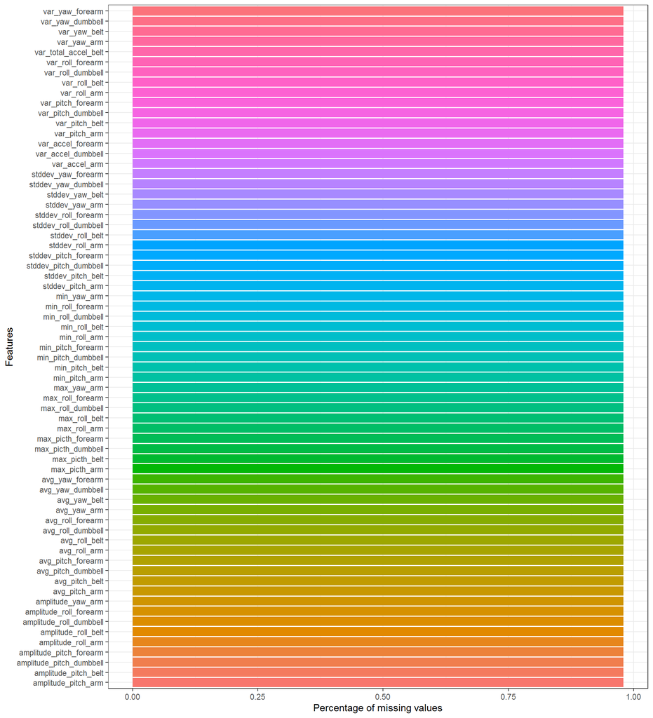

```r
miss<-miss[miss>0]
miss<-as.data.frame(miss)
Features<-rownames(miss)
miss<-mutate(miss, Features = Features)
theme_set(
theme_bw() +
theme(legend.position = "none")
)
g<-ggplot(miss, aes(x = Features, y= miss, fill = Features))+geom_bar(stat= "identity")+ coord_flip()+labs(y = "Percentage of missing values")
g
```

## Removing all the columns with very large proportion of NA values

```r
##Total no of columns to remove
length(Features)
```

```
## [1] 67
```

```r
numeric_data<-select(numeric_data,-c(Features))
dim(numeric_data)
```

```
## [1] 19622    52
```

```r
##colnames(numeric_data)
```

## Exploratory data analysis for the numerical data

## Finding the correlation between different variables in the numerical data columns

```r
##Finding correlation between different features
M<-abs(cor(numeric_data[,-52]))
diag(M)<-0
which(M > 0.8,arr.ind=T)
```

```
##                  row col
## yaw_belt           3   1
## total_accel_belt   4   1
## accel_belt_y       9   1
## accel_belt_z      10   1
## accel_belt_x       8   2
## magnet_belt_x     11   2
## roll_belt          1   3
## roll_belt          1   4
## accel_belt_y       9   4
## accel_belt_z      10   4
## pitch_belt         2   8
## magnet_belt_x     11   8
## roll_belt          1   9
## total_accel_belt   4   9
## accel_belt_z      10   9
## roll_belt          1  10
## total_accel_belt   4  10
## accel_belt_y       9  10
## pitch_belt         2  11
## accel_belt_x       8  11
## gyros_arm_y       19  18
## gyros_arm_x       18  19
## magnet_arm_x      24  21
## accel_arm_x       21  24
## magnet_arm_z      26  25
## magnet_arm_y      25  26
## accel_dumbbell_x  34  28
## accel_dumbbell_z  36  29
## gyros_dumbbell_z  33  31
## gyros_forearm_z   46  31
## gyros_dumbbell_x  31  33
## gyros_forearm_z   46  33
## pitch_dumbbell    28  34
## yaw_dumbbell      29  36
## gyros_forearm_z   46  45
## gyros_dumbbell_x  31  46
## gyros_dumbbell_z  33  46
## gyros_forearm_y   45  46
```

Since we can see the features with the similar names and different axis are highly correlated we can use PCA for optimizing the no of features required to build a model. However, for this assignment if the accuracy of our model is good enough, we may skip it.

## Exploring the categorical data

```r
str(cat_data)
```

```
## 'data.frame':    19622 obs. of  37 variables:
##  $ user_name              : Factor w/ 6 levels "adelmo","carlitos",..: 2 2 2 2 2 2 2 2 2 2 ...
##  $ cvtd_timestamp         : Factor w/ 20 levels "02/12/2011 13:32",..: 9 9 9 9 9 9 9 9 9 9 ...
##  $ new_window             : Factor w/ 2 levels "no","yes": 1 1 1 1 1 1 1 1 1 1 ...
##  $ kurtosis_roll_belt     : Factor w/ 397 levels "","-0.016850",..: 1 1 1 1 1 1 1 1 1 1 ...
##  $ kurtosis_picth_belt    : Factor w/ 317 levels "","-0.021887",..: 1 1 1 1 1 1 1 1 1 1 ...
##  $ kurtosis_yaw_belt      : Factor w/ 2 levels "","#DIV/0!": 1 1 1 1 1 1 1 1 1 1 ...
##  $ skewness_roll_belt     : Factor w/ 395 levels "","-0.003095",..: 1 1 1 1 1 1 1 1 1 1 ...
##  $ skewness_roll_belt.1   : Factor w/ 338 levels "","-0.005928",..: 1 1 1 1 1 1 1 1 1 1 ...
##  $ skewness_yaw_belt      : Factor w/ 2 levels "","#DIV/0!": 1 1 1 1 1 1 1 1 1 1 ...
##  $ max_yaw_belt           : Factor w/ 68 levels "","-0.1","-0.2",..: 1 1 1 1 1 1 1 1 1 1 ...
##  $ min_yaw_belt           : Factor w/ 68 levels "","-0.1","-0.2",..: 1 1 1 1 1 1 1 1 1 1 ...
##  $ amplitude_yaw_belt     : Factor w/ 4 levels "","#DIV/0!","0.00",..: 1 1 1 1 1 1 1 1 1 1 ...
##  $ kurtosis_roll_arm      : Factor w/ 330 levels "","-0.02438",..: 1 1 1 1 1 1 1 1 1 1 ...
##  $ kurtosis_picth_arm     : Factor w/ 328 levels "","-0.00484",..: 1 1 1 1 1 1 1 1 1 1 ...
```

[output cut: 23 more lines]

We can observe 2 major things for the categorical data:

```r
##Converting numerical factor variable as numerical variable
cat_data<-cat_data[,-(1:3)]
##colnames(cat_data)
cat_data<-sapply(select(cat_data,-c('classe')),function(x) x<-as.numeric(levels(x)[x]))
cat_data<-as.data.frame(cat_data)
cat_data<-mutate(cat_data,classe = train$classe)
```

## Finding columns with missing values in categorical data

```r
miss<-sapply(cat_data[,-34], function(x) mean(is.na(x)))
head(miss)
```

```
##   kurtosis_roll_belt  kurtosis_picth_belt    kurtosis_yaw_belt
##            0.9798186            0.9809398            1.0000000
##   skewness_roll_belt skewness_roll_belt.1    skewness_yaw_belt
##            0.9797676            0.9809398            1.0000000
```

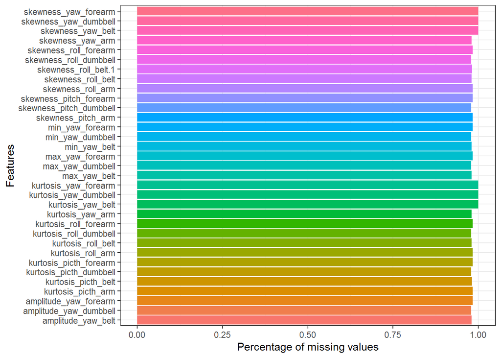

```r
miss<-miss[miss>0]
miss<-as.data.frame(miss)
Features = rownames(miss)
theme_set(
theme_bw() +
theme(legend.position = "none")
)
ggplot(miss, aes(x = Features, y= miss, fill = Features))+geom_bar(stat= "identity")+ coord_flip()+labs(y = "Percentage of missing values")
```

```r
cat_data<-select(cat_data,-c(Features))
dim(cat_data)
```

```
## [1] 19622     1
```

```r
str(cat_data)
```

```
## 'data.frame':    19622 obs. of  1 variable:
##  $ classe: Factor w/ 5 levels "A","B","C","D",..: 1 1 1 1 1 1 1 1 1 1 ...
```

## Creating new dataset with the left numerical and categorical variables that we will use for model building

```r
numeric_data<-cbind(numeric_data,classe = cat_data[,c('classe')])

##Creating test and train datasets for model building and evaluation
inTrain <- createDataPartition(y=numeric_data$classe,p=0.7, list=FALSE)
trainDS<-numeric_data[inTrain,]
testDS<-numeric_data[-inTrain,]
dim(trainDS)
```

```
## [1] 13737    53
```

```r
dim(testDS)
```

```
## [1] 5885   53
```

## Model building

In this we build two models using Random Forest and GBM which is a boosting algorithm and helps in combining predictors. Then we finally use the most accurate model

1. Using Random Forest

```r
##creating Random forest model and checking it accuracy
set.seed(12345)
controlRF <- trainControl(method="cv", number=3, verboseIter=FALSE)
modFitRandForest <- train(classe ~ ., data=trainDS, method="rf",trControl=controlRF)
modFitRandForest$finalModel
```

```
##
## Call:
##  randomForest(x = x, y = y, mtry = param$mtry)
##                Type of random forest: classification
##                      Number of trees: 500
## No. of variables tried at each split: 2
##
##         OOB estimate of  error rate: 0.74%
## Confusion matrix:
##      A    B    C    D    E class.error
## A 3901    3    1    0    1 0.001280082
## B   16 2634    8    0    0 0.009029345
## C    0   22 2369    5    0 0.011268781
## D    0    0   36 2215    1 0.016429840
## E    0    0    4    5 2516 0.003564356
```

```r
predictrf<-predict(modFitRandForest, newdata=testDS)
confrf<-confusionMatrix(predictrf, testDS$classe)
confrf
```

```
## Confusion Matrix and Statistics
##
##           Reference
## Prediction    A    B    C    D    E
##          A 1673    7    0    0    0
##          B    1 1130    9    0    0
##          C    0    2 1017   18    0
##          D    0    0    0  945    2
##          E    0    0    0    1 1080
##
## Overall Statistics
##
##                Accuracy : 0.9932
##                  95% CI : (0.9908, 0.9951)
##     No Information Rate : 0.2845
##     P-Value [Acc > NIR] : < 2.2e-16
##
##                   Kappa : 0.9914
##
##  Mcnemar's Test P-Value : NA
##
## Statistics by Class:
##
##                      Class: A Class: B Class: C Class: D Class: E
## Sensitivity            0.9994   0.9921   0.9912   0.9803   0.9982
## Specificity            0.9983   0.9979   0.9959   0.9996   0.9998
## Pos Pred Value         0.9958   0.9912   0.9807   0.9979   0.9991
## Neg Pred Value         0.9998   0.9981   0.9981   0.9962   0.9996
## Prevalence             0.2845   0.1935   0.1743   0.1638   0.1839
## Detection Rate         0.2843   0.1920   0.1728   0.1606   0.1835
## Detection Prevalence   0.2855   0.1937   0.1762   0.1609   0.1837
## Balanced Accuracy      0.9989   0.9950   0.9936   0.9899   0.9990
```

2. Using gbm

```r
##Creating gbm model and checking its accuracy
ctrlGBM <- trainControl(method = "repeatedcv", number = 5, repeats = 1)
modGBM<-train(classe~.,data = trainDS,method = "gbm",trControl = ctrlGBM,verbose = FALSE)
modGBM$finalModel
```

```
## A gradient boosted model with multinomial loss function.
## 150 iterations were performed.
## There were 52 predictors of which 52 had non-zero influence.
```

```r
predictGBM<-predict(modGBM,testDS)
confGBM<-confusionMatrix(predictGBM,testDS$classe)
confGBM
```

```
## Confusion Matrix and Statistics
##
##           Reference
## Prediction    A    B    C    D    E
##          A 1648   48    0    0    0
##          B   14 1070   31    3    7
##          C    7   18  976   30   14
##          D    5    3   16  926   13
##          E    0    0    3    5 1048
##
## Overall Statistics
##
##                Accuracy : 0.9631
##                  95% CI : (0.958, 0.9678)
##     No Information Rate : 0.2845
##     P-Value [Acc > NIR] : < 2.2e-16
##
##                   Kappa : 0.9533
##
##  Mcnemar's Test P-Value : NA
##
## Statistics by Class:
##
##                      Class: A Class: B Class: C Class: D Class: E
## Sensitivity            0.9845   0.9394   0.9513   0.9606   0.9686
## Specificity            0.9886   0.9884   0.9858   0.9925   0.9983
## Pos Pred Value         0.9717   0.9511   0.9340   0.9616   0.9924
## Neg Pred Value         0.9938   0.9855   0.9897   0.9923   0.9930
## Prevalence             0.2845   0.1935   0.1743   0.1638   0.1839
## Detection Rate         0.2800   0.1818   0.1658   0.1573   0.1781
## Detection Prevalence   0.2882   0.1912   0.1776   0.1636   0.1794
## Balanced Accuracy      0.9865   0.9639   0.9685   0.9765   0.9835
```

We observe that the accuracy of Random forest for the given problem is more than GBM. Therefore we will use it for making predictions in the quiz.